# Geospatial Risk Predictions

# 9 A table of MAE and standard deviation MAE by regression.

The graph shows the mean absolute error (MAE) and the mean absolute error standard deviation (MAESTD) of the model for cannabis arrest predictions. The MAE is a measure of the average difference between the predicted and actual values of the dependent variable. The MAESTD is a measure of the variability of the MAE.

```r
reg.ss.spatialCV_nogeom <- reg.ss.spatialCV %>%
  st_drop_geometry() %>%
  summarise(MAE = mean(countNarco.AbsError),
            MAESTD = sd(countNarco.AbsError)) %>%
  kbl(col.name=c('Mean Absolute Error','Mean Absolute Error Standard Deviation')) %>%
  kable_classic()

reg.ss.spatialCV_nogeom
```

| Mean Absolute Error | Mean Absolute Error Standard Deviation |
| --- | --- |
| 1.086479 | 2.557225 |

# 10 The map comparing kernel density to risk predictions for the next year’s crime.

## 10.1 Get 2018 crime data

```r
narcs18 <-
  read.socrata("https://data.cityofchicago.org/Public-Safety/Crimes-2018/3i3m-jwuy") %>%
  filter(Primary.Type == "NARCOTICS") %>%
  mutate(x = gsub("[()]", "", Location)) %>%
  separate(x,into= c("Y","X"), sep=",") %>%
  mutate(X = as.numeric(X),
         Y = as.numeric(Y)) %>%
  na.omit %>%
  st_as_sf(coords = c("X", "Y"), crs = 4326, agr = "constant") %>%
  st_transform('ESRI:102271') %>%
  distinct() %>%
  .[fishnet,]
```

```r
narc_ppp <- as.ppp(st_coordinates(drugArrest), W = st_bbox(final_net))
narc_KD.1000 <- spatstat.explore::density.ppp(narc_ppp, 1000)
narc_KD.1500 <- spatstat.explore::density.ppp(narc_ppp, 1500)
narc_KD.2000 <- spatstat.explore::density.ppp(narc_ppp, 2000)
narc_KD.df <- rbind(
  mutate(data.frame(rasterToPoints(mask(raster(narc_KD.1000), as(neighborhoods, 'Spatial')))), Legend = "1000 Ft."),
  mutate(data.frame(rasterToPoints(mask(raster(narc_KD.1500), as(neighborhoods, 'Spatial')))), Legend = "1500 Ft."),
  mutate(data.frame(rasterToPoints(mask(raster(narc_KD.2000), as(neighborhoods, 'Spatial')))), Legend = "2000 Ft."))

narc_KD.df$Legend <- factor(narc_KD.df$Legend, levels = c("1000 Ft.", "1500 Ft.", "2000 Ft."))

narc_KDE_sum <- as.data.frame(narc_KD.1000) %>%
  st_as_sf(coords = c("x", "y"), crs = st_crs(final_net)) %>%
  aggregate(., final_net, mean)
kde_breaks <- classIntervals(narc_KDE_sum$value,
                             n = 5, "fisher")
narc_KDE_sf <- narc_KDE_sum %>%
  mutate(label = "Kernel Density",
         Risk_Category = classInt::findCols(kde_breaks),
         Risk_Category = case_when(
           Risk_Category == 5 ~ "5th",
           Risk_Category == 4 ~ "4th",
           Risk_Category == 3 ~ "3rd",
           Risk_Category == 2 ~ "2nd",
           Risk_Category == 1 ~ "1st")) %>%
  cbind(
    aggregate(
      dplyr::select(narcs18) %>% mutate(countNarco = 1), ., sum) %>%
    mutate(countNarco = replace_na(countNarco, 0))) %>%
  dplyr::select(label, Risk_Category, countNarco)
```

```r
ml_breaks <- classIntervals(reg.ss.spatialCV$Prediction,
                             n = 5, "fisher")
narc_risk_sf <-
  reg.ss.spatialCV %>%
  mutate(label = "Risk Predictions",
         Risk_Category =classInt::findCols(ml_breaks),
         Risk_Category = case_when(
           Risk_Category == 5 ~ "5th",
           Risk_Category == 4 ~ "4th",
           Risk_Category == 3 ~ "3rd",
           Risk_Category == 2 ~ "2nd",
           Risk_Category == 1 ~ "1st")) %>%
  cbind(
    aggregate(
      dplyr::select(narcs18) %>% mutate(countNarco = 1), ., sum) %>%
      mutate(countNarco = replace_na(countNarco, 0))) %>%
  dplyr::select(label,Risk_Category, countNarco)
```

## 10.2 Kernel Density to Predict Next Year’s Narcotic Arrests

The first map shows kernel density of equal densities while the second map breaks them down into categories for a test set. The Kernel Density maps acts like a hotspot map in a way where it shows where all the points are most concentrated, requiring a test set of its own. The prediction risk categories uses each as a model to predict how at risk you are for being arrested for cannabis possession based on where you live.

For the risk predictions map, while each category alone doesn’t signify the risk, these are broken down into areas that all had the same density of clusters, hence why the third category is broken into two, it is covering where both of the major clusters were, the west and south side.

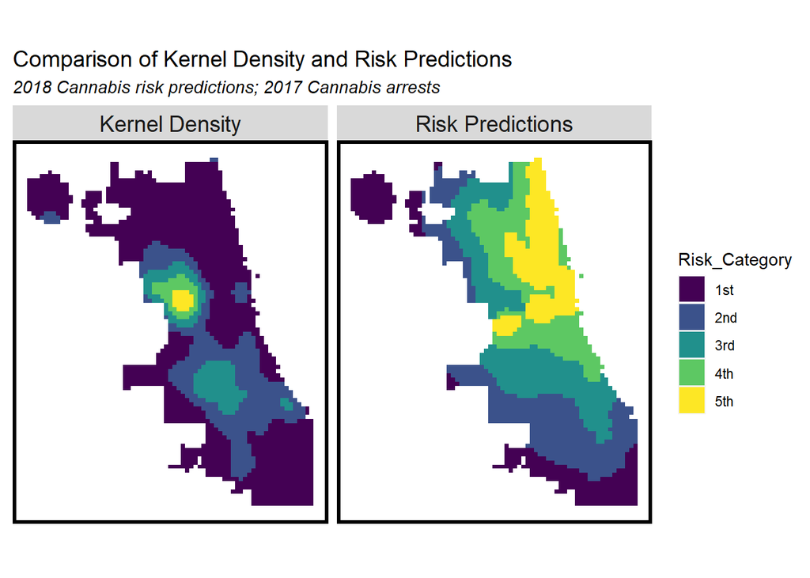

```r
rbind(narc_KDE_sf, narc_risk_sf) %>%
  na.omit() %>%
  gather(Variable, Value, -label, -Risk_Category, -geometry) %>%
  ggplot() +
    geom_sf(aes(fill = Risk_Category), colour = NA) +
    facet_wrap(~label, ) +
    scale_fill_viridis(discrete = TRUE) +
    labs(title="Comparison of Kernel Density and Risk Predictions",
         subtitle="2018 Cannabis risk predictions; 2017 Cannabis arrests") +
    mapTheme(title_size = 14)
```